# Week 9 Lab 2 — Shock-aligned DeepONet for a rarefied micro-nozzle

**Runtime:** CPU, normally under 4 minutes. **Prerequisites:** DSMC sampling, POD/SVD, case-wise validation, and DeepONet branch--trunk notation.

This lab uses compact full-field and centerline derivatives of **all 15 real public DSMC snapshots** from the Roohi--Mahdavi article *Shock-centered low-rank structure and shock-aligned surrogate modeling of rarefied micro-nozzle flows* (Physics of Fluids 38, 082008, 2026; DOI `10.1063/5.0343101`). It asks why a moving shock is high-rank in laboratory coordinates and low-rank in shock-centered coordinates.

### Learning outcomes

1. audit snapshot provenance and source hashes before learning;
2. detect a centerline compression station and identify noisy outliers;
3. reproduce the 15-snapshot physical versus shock-centered density POD audit;
4. select POD rank by leave-one-case-out development error;
5. open pressures 16, 25, and 30 kPa only after freezing the model;
6. generate fresh 2-D predictions for all six article outputs; and
7. compare classroom baselines and article tables as separate evidence levels.

## Evidence and claim contract

- `nozzle_fields_15cases.npz` and `nozzle_centerline_15cases.npz` are derived from the public Tecplot DSMC files at pinned commit `e1b234ba499408d3b6224633972f939f3b2301d6` and remain CC BY 4.0.
- The POD spectrum is directly reproducible from those data.
- The notebook first predicts jump-normalized centerline density, then compares physical-coordinate and shock-aligned interpolation baselines for density, $U$, $V$, temperature, Mach, and pressure. Both use the same 12 development fields; the shock surface for a query is interpolated only from source fields.
- The article metric tables are immutable retained evidence with a different output domain and must not be merged numerically with notebook errors.
- Shock centering uses target-derived locations in the structural POD and normalized-profile audit. For deployment, a shock-location model using only input pressure and training cases is separately tested below.

```python
# FLOWMLLAB_COLAB_BOOTSTRAP_V1
from pathlib import Path as _FlowMLLabPath
import os as _flowmllab_os
import subprocess as _flowmllab_subprocess
import sys as _flowmllab_sys

if "google.colab" in _flowmllab_sys.modules or _flowmllab_os.environ.get("COLAB_RELEASE_TAG"):
    _flowmllab_root = _FlowMLLabPath("/content/FlowMLLab")
    if not (_flowmllab_root / ".git").is_dir():
        _flowmllab_subprocess.run(
            ["git", "clone", "--depth", "1",
             "https://github.com/Ehsan-Roohi/FlowMLLab.git", str(_flowmllab_root)],
            check=True,
        )
    _flowmllab_subprocess.run(
        [_flowmllab_sys.executable, "-m", "pip", "install", "-q", "-e", str(_flowmllab_root)],
        check=True,
    )
    _flowmllab_os.chdir(_flowmllab_root / "notebooks/week09")

from pathlib import Path
import json
import platform
import warnings
import numpy as np
import pandas as pd
import matplotlib.pyplot as plt
try:
    from IPython.display import display
except ModuleNotFoundError:
    display = print

REPO_ROOT = next(
    candidate for candidate in (Path.cwd(), *Path.cwd().parents)
    if (candidate / "results/mahdavi_deeponet").is_dir()
)
if str(REPO_ROOT) not in _flowmllab_sys.path:
    _flowmllab_sys.path.insert(0, str(REPO_ROOT))
RESULTS = REPO_ROOT / "results/mahdavi_deeponet"
plt.rcParams.update({"font.size": 11, "axes.labelsize": 12, "legend.fontsize": 9})
print("Python:", platform.python_version())
print("FlowMLLab root:", REPO_ROOT)
```

```
Python: 3.12.14
FlowMLLab root: <FlowMLLab checkout>
```

```python
from sklearn.exceptions import ConvergenceWarning, DataConversionWarning
from sklearn.linear_model import Ridge
from sklearn.neural_network import MLPRegressor
from sklearn.pipeline import make_pipeline
from sklearn.preprocessing import PolynomialFeatures, StandardScaler

from flowmllab.mahdavi_deeponet import (
    NOZZLE_HELD_OUT_KPA,
    density_snapshot_matrix,
    load_nozzle_centerlines,
    pod_spectrum,
    relative_l2,
    validate_week9_evidence,
)

warnings.filterwarnings("ignore", category=ConvergenceWarning)
warnings.filterwarnings("ignore", category=DataConversionWarning)
report = validate_week9_evidence(REPO_ROOT)
public_report = {
    "status": report["status"],
    "nozzle_cases": report["nozzle_cases"],
    "held_out_pressures_kpa": report["held_out_pressures_kpa"],
    "physical_density_pod": report["physical_density_pod"],
    "shock_centered_density_pod": report["shock_centered_density_pod"],
    "full_field_validation": {
        "status": report["nozzle_flowmllab_validation"]["status"],
        "development_pressures_kpa": report["nozzle_flowmllab_validation"][
            "development_pressures_kpa"
        ],
        "held_out_pressures_kpa": report["nozzle_flowmllab_validation"][
            "held_out_pressures_kpa"
        ],
        "selected_method_by_field": report["nozzle_flowmllab_validation"][
            "selected_method_by_field"
        ],
    },
}
print(json.dumps(public_report, indent=2))
```

```
{
  "status": "pass",
  "nozzle_cases": 15,
  "held_out_pressures_kpa": [
    16,
    25,
    30
  ],
  "physical_density_pod": {
    "E1_percent": 78.9221278034391,
    "E12_percent": 88.4667706667226,
    "E123_percent": 93.7617868849599,
    "N99": 8
  },
  "shock_centered_density_pod": {
    "E1_percent": 97.98647751141955,
    "E12_percent": 99.18230342280253,
    "E123_percent": 99.86473811309618,
    "N99": 2
  },
  "full_field_validation": {
    "status": "pass",
    "development_pressures_kpa": [
      15,
      18,
      19,
      20,
      22,
      23,
      24,
      26,
      27,
      28,
      29,
      33
    ],
    "held_out_pressures_kpa": [
      16,
      25,
      30
    ],
    "selected_method_by_field": {
      "density": "shock_aligned",
      "mach": "shock_aligned",
      "pressure_tecplot": "shock_aligned",
      "temperature_k": "shock_aligned",
      "u_ms": "shock_aligned",
      "v_ms": "physical_coordinate"
    }
  }
}
```

## 1. Data audit before model fitting

The source files span back pressures from 15 to 33 kPa. Each main zone is 101 by 31; this teaching archive retains the exported max-$y$ boundary row and seven recorded fields. `pressure_tecplot` keeps the original file values without inferring a unit not stated by the Tecplot header.

The compact file is not a new simulation. Its provenance records every source filename and SHA-256, the exact source commit, the extraction rule, the derived file hash, and the licensing change notice.

**The exported symmetry values are not boundary-consistent.** The max-$y$ row lies at $y=92\,\mu$m, the stated symmetry plane, but its raw $V$ reaches about $-4.31$ m/s at 16 kPa. The physical boundary requires $V=0$. The archived Fortran exporter assigns adjacent cell values to boundary nodes without odd reflection of $V$; this is consistent with the observed defect, although the exact producing executable for these files has not been recovered. Matching that curve measures agreement with an exported label, not physical validity. The original arrays remain unchanged for provenance. The separate `predict_with_symmetry(..., symmetry_y_m=92e-6)` interface imposes the known boundary on predictions, leaves interior values unchanged, and does not contribute to the reported raw-data accuracy improvement. Repairing the exact DSMC export and checking the interior remain necessary.

```python
data = load_nozzle_centerlines(REPO_ROOT)
pressure = data["pressure_kpa"]
x_um = data["x_m"] * 1e6
held_out = np.isin(pressure, NOZZLE_HELD_OUT_KPA)
development = ~held_out

audit = pd.DataFrame({
    "pressure_kPa": pressure.astype(int),
    "split": np.where(held_out, "held out", "development"),
    "shock_x_um": data["shock_x_m"] * 1e6,
    "delta_jump_um": data["delta_jump_m"] * 1e6,
})
display(audit)
print("density array:", data["density"].shape)
print("held-out pressures:", pressure[held_out].astype(int).tolist())
assert pressure[held_out].astype(int).tolist() == [16, 25, 30]
```

|  | pressure_kPa | split | shock_x_um | delta_jump_um |
| --- | --- | --- | --- | --- |
| 0 | 15 | development | 168.099999 | 7.381729 |
| 1 | 16 | held out | 163.999997 | 7.712811 |
| 2 | 18 | development | 153.750007 | 7.376821 |
| 3 | 19 | development | 143.500001 | 7.663521 |
| 4 | 20 | development | 135.299997 | 7.432425 |
| 5 | 22 | development | 147.600003 | 9.838734 |
| 6 | 23 | development | 120.949997 | 7.513011 |
| 7 | 24 | development | 123.000005 | 7.507697 |
| 8 | 25 | held out | 114.800001 | 7.343256 |
| 9 | 26 | development | 108.649998 | 7.244510 |
| 10 | 27 | development | 106.599997 | 6.971312 |
| 11 | 28 | development | 106.599997 | 6.930624 |
| 12 | 29 | development | 102.500002 | 6.888377 |
| 13 | 30 | held out | 96.349999 | 6.359925 |
| 14 | 33 | development | 96.349999 | 6.319889 |

```
density array: (15, 101)
held-out pressures: [16, 25, 30]
```

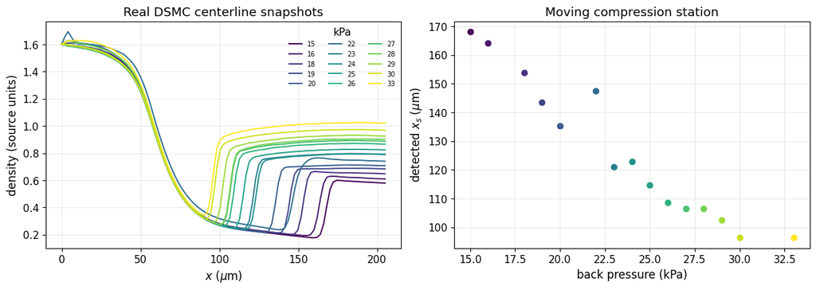

```python
fig, axes = plt.subplots(1, 2, figsize=(12, 4.2), constrained_layout=True)
colors = plt.cm.viridis(np.linspace(0, 1, len(pressure)))
for index, (p_value, color) in enumerate(zip(pressure, colors)):
    axes[0].plot(x_um, data["density"][index], color=color, lw=1.4, label=f"{p_value:g}")
    axes[1].scatter(p_value, data["shock_x_m"][index] * 1e6, color=color, s=36)
axes[0].set(xlabel=r"$x$ ($\mu$m)", ylabel="density (source units)", title="Real DSMC centerline snapshots")
axes[1].set(xlabel="back pressure (kPa)", ylabel=r"detected $x_s$ ($\mu$m)", title="Moving compression station")
axes[0].grid(alpha=.25)
axes[1].grid(alpha=.25)
axes[0].legend(title="kPa", ncol=3, fontsize=7, frameon=False)
plt.show()
```

The detector chooses the largest smoothed interior density gradient, then estimates a jump width $\delta_j=|\rho_L-\rho_R|/|\partial\rho/\partial x|_{x_s}$. At 22 kPa the automatic station is visibly non-monotone. Retaining that point is important: a shock sensor is a model component that also needs validation, not an infallible preprocessing oracle.

## 2. Structural audit: moving discontinuity versus aligned structure

For each case, define

$$ \xi_j=\frac{x-x_s}{\delta_j}, \qquad \widetilde\rho=\frac{\rho-\rho_R}{\rho_L-\rho_R}. $$

First use all 15 cases only for the published **representation audit**, not for model selection. This answers how compact the snapshot family is after a known coordinate transform. It does not estimate held-out model accuracy.

|  | coordinate | E1_percent | E12_percent | E123_percent | N99 |
| --- | --- | --- | --- | --- | --- |
| 0 | physical | 78.922128 | 88.466771 | 93.761787 | 8 |
| 1 | shock_centered | 97.986478 | 99.182303 | 99.864738 | 2 |

|  | coordinate | E1_percent | E12_percent | E123_percent | N99 | evidence_status |
| --- | --- | --- | --- | --- | --- | --- |
| 0 | physical | 78.922112 | 88.466789 | 93.761787 | 8 | published source-repository reference output |
| 1 | shock_centered | 97.985513 | 99.182179 | 99.864828 | 2 | published source-repository reference output |

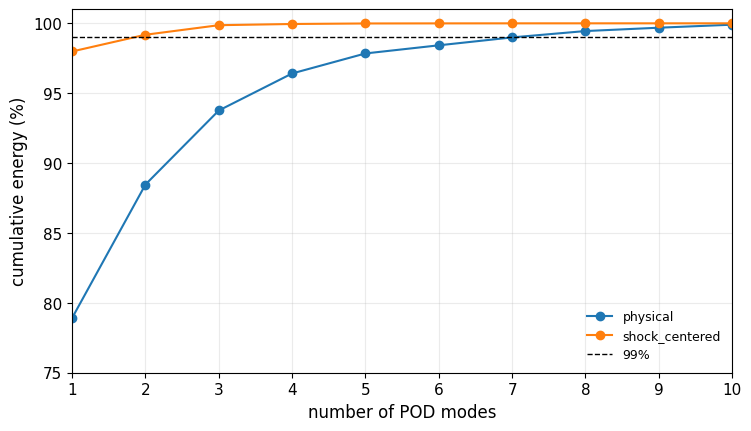

```python
pod_rows = []
matrices = {}
grids = {}
for coordinate in ("physical", "shock_centered"):
    grid, matrix = density_snapshot_matrix(
        data["x_m"], data["density"], data["shock_x_m"], data["delta_jump_m"],
        coordinate=coordinate,
    )
    spectrum = pod_spectrum(matrix)
    grids[coordinate], matrices[coordinate] = grid, matrix
    pod_rows.append({
        "coordinate": coordinate,
        "E1_percent": spectrum["first_mode_percent"],
        "E12_percent": spectrum["first_two_percent"],
        "E123_percent": spectrum["first_three_percent"],
        "N99": spectrum["n99"],
    })
pod_observed = pd.DataFrame(pod_rows)
pod_reference = pd.read_csv(RESULTS / "nozzle_pod_reference.csv")
display(pod_observed)
display(pod_reference)

fig, ax = plt.subplots(figsize=(7.4, 4.2), constrained_layout=True)
for coordinate, matrix in matrices.items():
    cumulative = pod_spectrum(matrix)["cumulative_energy"] * 100
    ax.plot(np.arange(1, len(cumulative) + 1), cumulative, "o-", label=coordinate)
ax.axhline(99, color="black", ls="--", lw=1, label="99%")
ax.set(xlabel="number of POD modes", ylabel="cumulative energy (%)", ylim=(75, 101), xlim=(1, 10))
ax.grid(alpha=.25)
ax.legend(frameon=False)
plt.show()

assert pod_observed.set_index("coordinate").loc["physical", "N99"] == 8
assert pod_observed.set_index("coordinate").loc["shock_centered", "N99"] == 2
```

## 3. POD--DeepONet teaching analog with a frozen split

The POD modes act as a fixed trunk, $t_k(\xi)$. A one-input neural branch maps back pressure to modal coefficients, $b_k(P_b)$. The predicted normalized centerline profile is

$$ \widehat{\widetilde\rho}(P_b,\xi)=\bar\rho(\xi)+ \sum_{k=1}^{r} b_k(P_b)t_k(\xi). $$

```python
def make_branch():
    return make_pipeline(
        StandardScaler(),
        MLPRegressor(
            hidden_layer_sizes=(8,), activation="tanh", solver="lbfgs",
            alpha=0.01, max_iter=1500, random_state=690,
        ),
    )


def fit_predict_pod_branch(matrix, train_indices, query_indices, rank):
    train_matrix = matrix[train_indices]
    mean = train_matrix.mean(axis=0)
    _, _, modes = np.linalg.svd(train_matrix - mean, full_matrices=False)
    rank = min(rank, len(train_indices) - 1)
    coefficients = (train_matrix - mean) @ modes[:rank].T
    target = coefficients.ravel() if rank == 1 else coefficients
    branch = make_branch().fit(pressure[train_indices, None], target)
    predicted_coefficients = np.asarray(
        branch.predict(pressure[query_indices, None])
    ).reshape(len(query_indices), rank)
    return mean + predicted_coefficients @ modes[:rank]


development_indices = np.flatnonzero(development)
candidate_ranks = {
    "physical": [2, 4, 6, 8],
    "shock_centered": [1, 2, 3, 4],
}
selection_rows = []
for coordinate, ranks in candidate_ranks.items():
    matrix = matrices[coordinate]
    for rank in ranks:
        fold_errors = []
        for validation_index in development_indices:
            fold_train = development_indices[development_indices != validation_index]
            prediction = fit_predict_pod_branch(
                matrix, fold_train, np.array([validation_index]), rank
            )[0]
            fold_errors.append(100 * relative_l2(matrix[validation_index], prediction))
        selection_rows.append({
            "coordinate": coordinate,
            "rank": rank,
            "LOO_mean_percent": np.mean(fold_errors),
            "LOO_max_percent": np.max(fold_errors),
        })
selection = pd.DataFrame(selection_rows)
display(selection)
selected_rank = (
    selection.sort_values("LOO_mean_percent")
    .groupby("coordinate", as_index=False).first()
    .set_index("coordinate")["rank"].astype(int).to_dict()
)
print("selected ranks:", selected_rank)
```

|  | coordinate | rank | LOO_mean_percent | LOO_max_percent |
| --- | --- | --- | --- | --- |
| 0 | physical | 2 | 19.160736 | 29.686533 |
| 1 | physical | 4 | 18.699665 | 33.357870 |
| 2 | physical | 6 | 17.271347 | 36.882946 |
| 3 | physical | 8 | 17.383309 | 32.383287 |
| 4 | shock_centered | 1 | 11.014606 | 29.133900 |
| 5 | shock_centered | 2 | 10.714546 | 27.773818 |
| 6 | shock_centered | 3 | 12.008538 | 29.561609 |
| 7 | shock_centered | 4 | 11.169595 | 27.473980 |

```
selected ranks: {'physical': 6, 'shock_centered': 2}
```

## Stop: held-out pressure gate

The representation, split, branch architecture, seed, rank candidates, and selection statistic are now frozen. Predict which pressure will be hardest. Then open 16, 25, and 30 kPa exactly once.

|  | coordinate | rank | pressure_kPa | normalized_centerline_relative_L2_percent |
| --- | --- | --- | --- | --- |
| 0 | physical | 6 | 16 | 7.766777 |
| 1 | physical | 6 | 25 | 11.270119 |
| 2 | physical | 6 | 30 | 10.638597 |
| 3 | shock_centered | 2 | 16 | 2.836197 |
| 4 | shock_centered | 2 | 25 | 3.205056 |
| 5 | shock_centered | 2 | 30 | 11.496424 |

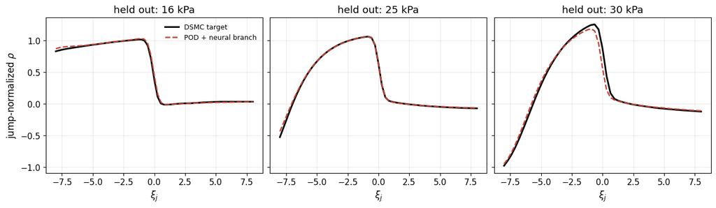

```python
held_out_indices = np.flatnonzero(held_out)
blind_rows = []
blind_predictions = {}
for coordinate in ("physical", "shock_centered"):
    prediction = fit_predict_pod_branch(
        matrices[coordinate], development_indices, held_out_indices,
        selected_rank[coordinate],
    )
    blind_predictions[coordinate] = prediction
    for local_index, case_index in enumerate(held_out_indices):
        blind_rows.append({
            "coordinate": coordinate,
            "rank": selected_rank[coordinate],
            "pressure_kPa": int(pressure[case_index]),
            "normalized_centerline_relative_L2_percent": 100 * relative_l2(
                matrices[coordinate][case_index], prediction[local_index]
            ),
        })
blind_metrics = pd.DataFrame(blind_rows)
display(blind_metrics)

fig, axes = plt.subplots(1, 3, figsize=(13, 3.7), constrained_layout=True, sharey=True)
for axis, local_index, case_index in zip(axes, range(3), held_out_indices):
    axis.plot(grids["shock_centered"], matrices["shock_centered"][case_index],
              color="black", lw=2.2, label="DSMC target")
    axis.plot(grids["shock_centered"], blind_predictions["shock_centered"][local_index],
              color="#C44536", lw=1.8, ls="--", label="POD + neural branch")
    axis.set(title=f"held out: {pressure[case_index]:g} kPa", xlabel=r"$\xi_j$")
    axis.grid(alpha=.25)
axes[0].set_ylabel(r"jump-normalized $\rho$")
axes[0].legend(frameon=False)
plt.show()
```

These are one-dimensional, jump-normalized representation errors. They are useful for comparing coordinate choices under a matched teaching model, but they are **not commensurate** with the paper's global 2-D raw-field errors. The expected pattern is also scientifically richer than “alignment always wins”: average aligned error decreases, yet the 30 kPa case can remain hard. Inspecting individual cases prevents a favorable mean from hiding that failure.

## 4. Can the shock location be predicted without target CFD?

The structural audit used target-derived $x_s$. A deployable operator cannot read the unseen density gradient first. Fit an intentionally transparent pressure-to-location baseline using the 12 development cases only, then test the three frozen pressures. This is a separate component-level validation.

```python
shock_locator = make_pipeline(
    StandardScaler(), PolynomialFeatures(2), Ridge(alpha=1e-6)
).fit(pressure[development, None], data["shock_x_m"][development] * 1e6)
predicted_shock_um = shock_locator.predict(pressure[held_out, None])
shock_table = pd.DataFrame({
    "pressure_kPa": pressure[held_out].astype(int),
    "DSMC_detected_xs_um": data["shock_x_m"][held_out] * 1e6,
    "training_only_predicted_xs_um": predicted_shock_um,
})
shock_table["absolute_error_um"] = abs(
    shock_table["training_only_predicted_xs_um"] - shock_table["DSMC_detected_xs_um"]
)
display(shock_table)
```

|  | pressure_kPa | DSMC_detected_xs_um | training_only_predicted_xs_um | absolute_error_um |
| --- | --- | --- | --- | --- |
| 0 | 16 | 163.999997 | 163.381346 | 0.618652 |
| 1 | 25 | 114.800001 | 117.427216 | 2.627215 |
| 2 | 30 | 96.349999 | 100.778767 | 4.428768 |

The 22 kPa detector outlier remains in development data, so it can degrade this simple locator. Do not delete it silently. Defensible next steps are to audit the sensor window, quantify detector uncertainty, predeclare a robust fit, and repeat the frozen test—not to tune directly on 16, 25, or 30 kPa.

## 5. Generate full-field interpolation baselines from FlowMLLab code

The following cell runs the repository's validation program. It compares plain physical-coordinate interpolation with row-wise shock-aligned interpolation. For each field, development-only LOO folds select alignment when it lowers shock-window error and increases global error by no more than two percentage points. The rule is frozen before evaluating 16, 25, and 30 kPa. These are interpolation baselines, not a newly trained DeepONet.

The program writes only to ignored `tmp/week09_lab2/`, never to retained `results/`. It produces a machine-readable selection table, 18 held-out rows with global, shock-window, and density-gradient-weighted metrics for both methods, an error heatmap, a 6-by-3 centerline comparison, and full 2-D comparisons. Article numbers remain in their own immutable CSV; no difference column is computed between non-commensurate evidence levels.

In the centerline figure, the $V$ panels show the prescribed symmetry condition $V=0$, not the inconsistent exported boundary samples. Raw $V$ curves remain in the separate symmetry audit below. No learned accuracy or relative error against a zero boundary profile is claimed; all CSV regression metrics still refer to the original raw fields.

| held_out_pressure_kpa field | 16 | 25 | 30 |
| --- | --- | --- | --- |
| density | 4.366171 | 4.130441 | 4.733840 |
| mach | 3.573526 | 5.984422 | 14.200069 |
| pressure_tecplot | 5.020241 | 4.539458 | 5.406357 |
| temperature_k | 1.751190 | 1.572179 | 2.893195 |
| u_ms | 3.107499 | 5.586308 | 12.038174 |
| v_ms | 10.813383 | 13.408876 | 12.592550 |

| held_out_pressure_kpa field | 16 | 25 | 30 |
| --- | --- | --- | --- |
| density | 1.706060 | 4.760946 | 15.344610 |
| mach | 3.978610 | 6.045135 | 19.485552 |
| pressure_tecplot | 2.310048 | 5.868831 | 18.730155 |
| temperature_k | 2.052478 | 2.564132 | 7.190345 |
| u_ms | 1.685370 | 5.270005 | 17.058346 |
| v_ms | 21.620585 | 20.888929 | 16.806873 |

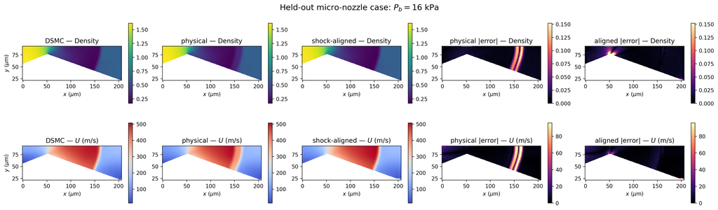

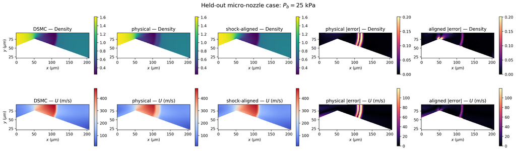

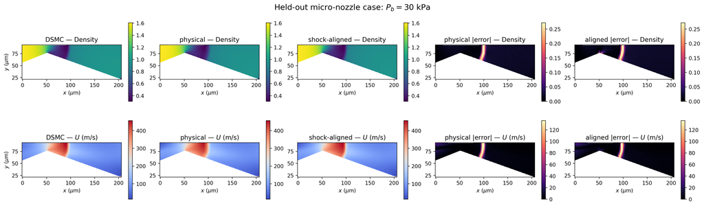

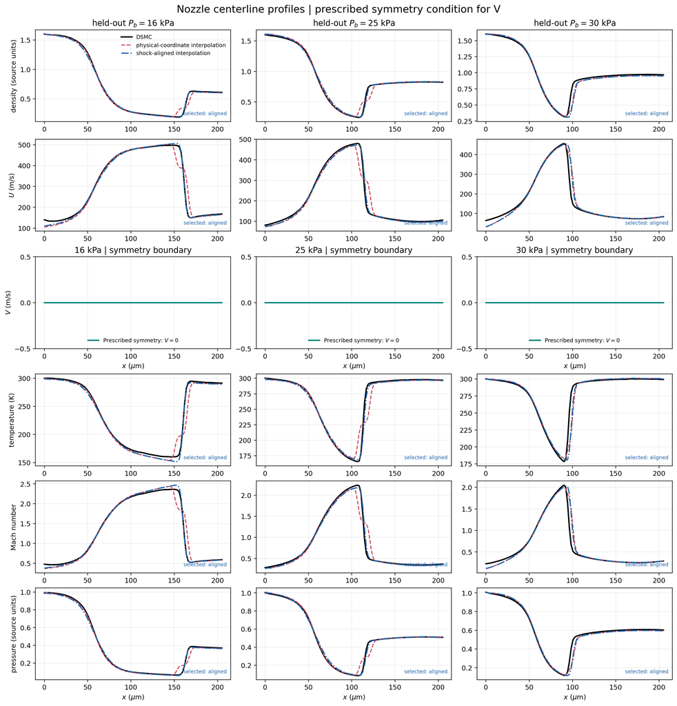

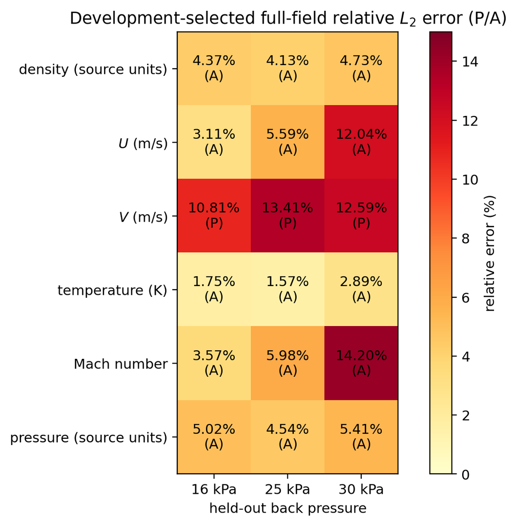

```python
command = [
    _flowmllab_sys.executable,
    str(REPO_ROOT / "qa/run_nozzle_field_validation.py"),
    "--root", str(REPO_ROOT),
    "--output-dir", str(REPO_ROOT / "tmp/week09_lab2"),
]
_flowmllab_subprocess.run(command, check=True)
GENERATED_RESULTS = REPO_ROOT / "tmp/week09_lab2"
generated_metrics = pd.read_csv(GENERATED_RESULTS / "nozzle_flowmllab_heldout_metrics.csv")
display(generated_metrics.pivot(
    index="field", columns="held_out_pressure_kpa",
    values="selected_global_relative_l2_percent",
))
display(generated_metrics.pivot(
    index="field", columns="held_out_pressure_kpa",
    values="selected_shock_window_relative_l2_percent",
))

try:
    from IPython.display import Image as _NozzleImage
except ModuleNotFoundError:
    _NozzleImage = None
if _NozzleImage is not None:
    for filename in (
        "nozzle_flowmllab/nozzle_back_pressure_P16_contours.png",
        "nozzle_flowmllab/nozzle_back_pressure_P25_contours.png",
        "nozzle_flowmllab/nozzle_back_pressure_P30_contours.png",
        "nozzle_flowmllab/nozzle_back_pressure_profiles.png",
        "nozzle_flowmllab/nozzle_back_pressure_error_summary.png",
    ):
        display(_NozzleImage(filename=str(GENERATED_RESULTS / filename)))
```

## 6. Registered POD models: a trained neural branch and a stronger baseline

The previous sensor sometimes selects the outlet gradient near the wall. Translating an entire row also moves the fixed throat. The new experiment searches for a **positive interior compression** and registers the field with a monotone map that fixes inlet, throat, and outlet. A robust quadratic predicts the compression station from training pressures. The 22 kPa development case is retained; its non-monotone station is not deleted or relabelled.

The registered, channel-scaled fields define a joint POD basis. Complete-case development folds compare ranks 2, 4, and 6, a quadratic coefficient branch, and tanh neural branches of width 8 or 16 with three seeds. Registration, normalization, and POD are recomputed inside each fold. Selection minimizes the mean six-field relative $L_2$ error. The polynomial branch wins; it must not be labelled a neural-network result. The separately trained neural ensemble is also retained, with convergence flags and seed dispersion.

The following cell uses frozen numerical checkpoints and reproduces the predictions without retraining. For the full development sweep, run `python qa/run_nozzle_transport_validation.py --stage all` from the repository root. The 16/25/30 kPa cases were inspected during earlier project work: these new results are a **regression assessment on historical holdouts**, not a fresh blind test. A new independent pressure sweep is needed for a research claim.

```
Selected coefficient branch: polynomial
Selected POD rank: 6
Neural ensemble rank/width: 2 8
```

| pressure_kpa field | 16 | 25 | 30 |
| --- | --- | --- | --- |
| density | 0.992980 | 1.250301 | 4.534749 |
| mach | 3.179061 | 1.915470 | 13.667246 |
| pressure_tecplot | 1.104389 | 1.599675 | 5.185899 |
| temperature_k | 1.102721 | 0.688232 | 2.782127 |
| u_ms | 2.708667 | 2.172803 | 11.600714 |
| v_ms | 5.827587 | 2.713067 | 12.560857 |

| pressure_kpa field | 16 | 25 | 30 |
| --- | --- | --- | --- |
| density | 1.280401 | 1.295596 | 4.434937 |
| mach | 3.510372 | 3.547222 | 13.393990 |
| pressure_tecplot | 1.495909 | 1.391160 | 5.111218 |
| temperature_k | 1.232728 | 0.585557 | 2.757670 |
| u_ms | 2.962018 | 3.860477 | 11.409661 |
| v_ms | 5.769416 | 6.301903 | 12.530577 |

|  | pressure_kpa | shock_station_mean_absolute_error_um | shock_station_max_absolute_error_um | reference_symmetry_v_rms_ms | reference_symmetry_v_max_abs_ms | reference_mass_flow_spread_percent | reference_positive_density_temperature_pressure | selected_symmetry_v_rms_ms | selected_symmetry_v_max_abs_ms | selected_mass_flow_spread_percent | selected_positive_density_temperature_pressure | selected_mass_flow_profile_relative_l2_percent | neural_symmetry_v_rms_ms | neural_symmetry_v_max_abs_ms | neural_mass_flow_spread_percent | neural_positive_density_temperature_pressure | neural_mass_flow_profile_relative_l2_percent |
| --- | --- | --- | --- | --- | --- | --- | --- | --- | --- | --- | --- | --- | --- | --- | --- | --- | --- |
| 0 | 16 | 0.585347 | 0.986915 | 1.989524 | 4.3103 | 6.334406 | True | 1.982950 | 4.372576 | 5.215924 | True | 1.144440 | 2.053640 | 4.672866 | 7.581047 | True | 1.919255 |
| 1 | 25 | 0.121671 | 0.216207 | 1.739093 | 4.2820 | 5.902675 | True | 1.690445 | 4.146077 | 6.441276 | True | 3.058634 | 1.720609 | 3.842860 | 10.492391 | True | 1.729799 |
| 2 | 30 | 3.430519 | 3.648305 | 1.635839 | 4.3566 | 5.869723 | True | 1.683313 | 4.213768 | 6.064530 | True | 2.071701 | 1.708497 | 4.386964 | 6.442658 | True | 1.375485 |

```
Raw-label regression is not physical validation: False
```

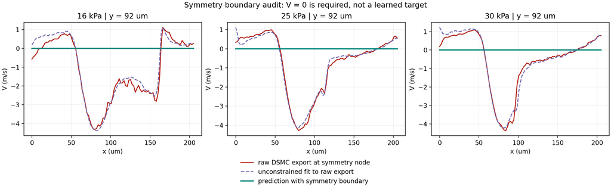

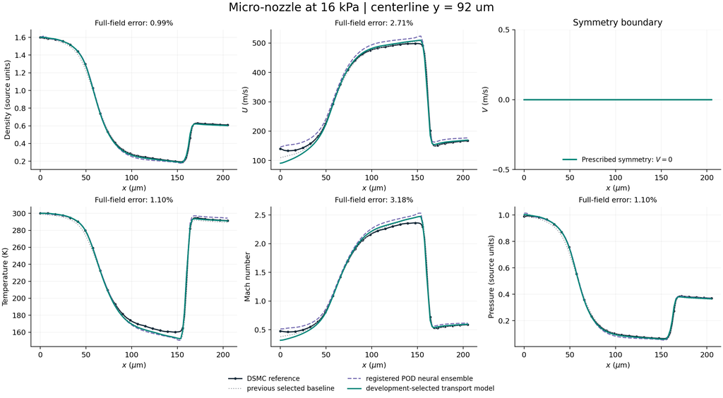

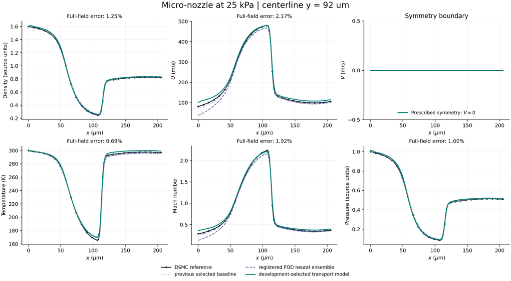

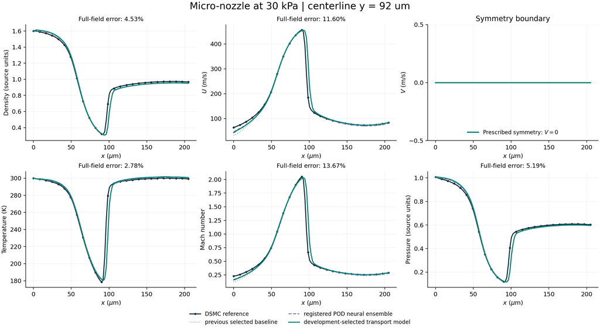

```python
from flowmllab.nozzle_transport import (
    load_transport_model, predict_transport_pod, predict_with_symmetry,
)

transport_dir = REPO_ROOT / "results/nozzle_transport"
transport_report = json.loads((transport_dir / "report.json").read_text())
transport_metrics = pd.read_csv(transport_dir / "regression_metrics.csv")
transport_model = load_transport_model(transport_dir / "selected_model.npz")
transport_prediction = predict_transport_pod(transport_model, [16.0, 25.0, 30.0])
with np.load(transport_dir / "predictions.npz", allow_pickle=False) as stored:
    np.testing.assert_allclose(transport_prediction, stored["selected"], rtol=1e-9, atol=1e-10)
print("Selected coefficient branch:", transport_report["selected_branch"])
print("Selected POD rank:", transport_report["selected_rank"])
print("Neural ensemble rank/width:", transport_report["neural_rank"], transport_report["neural_width"])
display(transport_metrics.pivot(index="field", columns="pressure_kpa",
                              values="selected_global_relative_l2_percent"))
display(transport_metrics.pivot(index="field", columns="pressure_kpa",
                              values="neural_global_relative_l2_percent"))
display(pd.read_csv(transport_dir / "physical_diagnostics.csv"))
symmetry_prediction = predict_with_symmetry(transport_model, [16, 25, 30], symmetry_y_m=92e-6)
np.testing.assert_array_equal(symmetry_prediction[:, -1, :, 2], 0.0)
print("Raw-label regression is not physical validation:", transport_report["physical_validation_passed"])
display(_NozzleImage(filename=str(transport_dir / "symmetry_boundary_audit.png")))
if _NozzleImage is not None:
    for pressure_kpa in (16, 25, 30):
        display(_NozzleImage(filename=str(transport_dir / f"nozzle_P{pressure_kpa}_profiles.png")))
```

The average full-field error decreases from 6.429% for the previous selected interpolation baseline to 4.199% for registered POD with a quadratic branch; the trained neural ensemble reaches 4.604%. At 25 kPa, the selected model's $U$ and $V$ errors are 2.173% and 2.713%. The 30 kPa case remains difficult: the pressure-only shock locator misses the compression station by 3.431 micrometres on average, with $U$ and Mach errors of 11.601% and 13.667%. Neither a sharper colormap nor a target-assisted shift would resolve this deployment limitation. Predictions are not clipped or smoothed after scoring.

The mass-flow profile error is also recorded (1.14%, 3.06%, and 2.07% for the selected model); this does not mean exact conservation. Even the source DSMC fields have about 6% streamwise mass-flow spread under this discrete diagnostic. The historical shock-window definition is retained for matched comparisons; the independently corrected station error is reported separately. The displayed $V$ centerline uses the separately stored boundary-constrained prediction; this plotting correction leaves model weights, raw fields, and scores unchanged. To rebuild just these panels, run `python qa/run_nozzle_transport_validation.py --stage profiles`.

## 7. Retained full-model paper evidence

The next tables are read from immutable CSV transcriptions. They describe the article's full two-dimensional held-out outputs and hard 16 kPa comparison; the notebook did not regenerate them.

```python
paper_fields = pd.read_csv(RESULTS / "nozzle_paper_field_errors.csv")
paper_baselines = pd.read_csv(RESULTS / "nozzle_hard_case_baselines.csv")
display(paper_fields.pivot(
    index="field", columns="held_out_pressure_kpa",
    values="reported_relative_l2_percent",
))
display(paper_baselines)
```

| held_out_pressure_kpa field | 16 | 25 | 30 |
| --- | --- | --- | --- |
| Mach | 13.2 | 8.7 | 10.0 |
| U | 11.2 | 7.5 | 8.9 |
| V | 14.8 | 7.6 | 5.3 |
| density | 4.8 | 3.3 | 3.3 |
| pressure | 6.8 | 3.8 | 3.8 |
| temperature | 4.3 | 2.0 | 1.9 |

|  | model | features | pressure_kpa | parameters | seeds | global_mean_percent | global_std_percent | shock_window_mean_percent | shock_window_std_percent | gradient_weighted_mean_percent | gradient_weighted_std_percent | evidence_status |
| --- | --- | --- | --- | --- | --- | --- | --- | --- | --- | --- | --- | --- |
| 0 | Cartesian Hadamard branch/trunk | xy | 16 | 132102 | 3 | 10.64 | 5.12 | 34.95 | 20.06 | 11.69 | 5.51 | retained final-article Table XIII evidence |
| 1 | Strong Cartesian MLP concat | xy | 16 | 148486 | 3 | 5.09 | 0.88 | 8.86 | 1.26 | 5.40 | 0.90 | retained final-article Table XIII evidence |
| 2 | Strong MLP concat plus d | d | 16 | 148614 | 3 | 5.14 | 0.86 | 9.50 | 2.43 | 5.50 | 0.98 | retained final-article Table XIII evidence |
| 3 | Shock-aligned reduced d | d | 16 | 132230 | 3 | 5.47 | 1.28 | 9.12 | 1.01 | 5.71 | 1.21 | retained final-article Table XIII evidence |
| 4 | Shock-aligned reduced no abs/d2 | no abs/d2 | 16 | 132742 | 3 | 6.40 | 3.16 | 16.09 | 9.53 | 7.13 | 3.60 | retained final-article Table XIII evidence |
| 5 | Full candidate feature set | full | 16 | 132998 | 3 | 6.32 | 2.34 | 13.41 | 5.05 | 6.98 | 2.69 | retained final-article Table XIII evidence |

The retained hard-case table shows why global error alone is insufficient. In the final article's three-seed comparison, the Cartesian Hadamard branch/trunk model has $34.95\pm20.06\%$ shock-window error. Adding the reduced signed distance lowers it to $9.12\pm1.01\%$, comparable to the strong Cartesian MLP's $8.86\pm1.26\%$. The defensible claim is therefore not universal superiority. The signed-distance representation removes a major translation burden for the branch/trunk model; the final article explicitly does not claim a new fusion architecture.

The method is physics-guided through representation, localized weighting, and shock-envelope features. It does **not** thereby become a PDE-constrained model: the reported formulation does not explicitly enforce a PDE residual, Rankine--Hugoniot jump, or global conservation law.

### Required submission

1. the data/provenance audit and held-out pressure list;
2. physical and aligned POD energy tables;
3. leave-one-case-out rank selection;
4. per-pressure held-out profile and shock-location errors;
5. the fresh 2-D FlowMLLab contour and full-field error table;
6. one documented failure or detector ambiguity; and
7. an explicit sentence distinguishing notebook-generated evidence from the paper's retained full-model evidence.

### Extension

Add conservation and mass-flux diagnostics to the two baselines, then implement a genuinely trained six-output operator using the same frozen split. A larger network is not automatically stronger when the number of independent CFD cases remains small.